# Pisemka 7ZAST 2019/20

R19353 - Lukas Stuchlik

1/6/2020

## Zadání Diamanty

V datech diamonds jsou data o 53940 různých diamantech.

1. Prozkoumejte data. Spočítejte popisné statistiky numerických proměnných.
2. Spočítejte frekvence kategorií v proměnných cut, color a clarity. Jak často se každá kategorie vyskytuje v datech.
3. Spočítejte 95-ti a 99-ti procentní oboustranné konfidenční intervaly pro proměnné carat, depth a price.
4. V proměnné cut jsou zaznamenány kategorie diamantů Fair, Good, Very Good, Premium, Ideal. Vyberte si dvě různé, kategorie a porovnejte je. Pro porovnání použijte proměnné carat, depth a price. Použijte t.testy apod. Své výsledky okomentujte. Můžete je porovnat i graficky.

```r
# Nápověda.
# Průměrnou cenu diamantu z kategorie "Fair" lze vypočítat:
mean(diamonds$price[diamonds$cut=="Fair"])
```

```
## [1] 4358.758
```

## Řešení Diamanty

### 1. Prozkoumejte data + popisné statistiky

V prvé řadě se podíváme na strukturu dat:

```r
str(diamonds)
```

```
## Classes 'tbl_df', 'tbl' and 'data.frame':    53940 obs. of  10 variables:
##  $ carat  : num  0.23 0.21 0.23 0.29 0.31 0.24 0.24 0.26 0.22 0.23 ...
##  $ cut    : Ord.factor w/ 5 levels "Fair"<"Good"<..: 5 4 2 4 2 3 3 3 1 3 ...
##  $ color  : Ord.factor w/ 7 levels "D"<"E"<"F"<"G"<..: 2 2 2 6 7 7 6 5 2 5 ...
##  $ clarity: Ord.factor w/ 8 levels "I1"<"SI2"<"SI1"<..: 2 3 5 4 2 6 7 3 4 5 ...
##  $ depth  : num  61.5 59.8 56.9 62.4 63.3 62.8 62.3 61.9 65.1 59.4 ...
##  $ table  : num  55 61 65 58 58 57 57 55 61 61 ...
##  $ price  : int  326 326 327 334 335 336 336 337 337 338 ...
##  $ x      : num  3.95 3.89 4.05 4.2 4.34 3.94 3.95 4.07 3.87 4 ...
##  $ y      : num  3.98 3.84 4.07 4.23 4.35 3.96 3.98 4.11 3.78 4.05 ...
##  $ z      : num  2.43 2.31 2.31 2.63 2.75 2.48 2.47 2.53 2.49 2.39 ...
```

Vidíme, že se jedná o soubor dat s 53940 pozorováními 10 různých proměnných - `carat, cut, color, clarity, depth, table, price, x, y, z`, přičemž s výjimkou `cut, color, clarity` se jedná o číselné proměnné. Taky můžeme vidět, kolik kategorií dané kategorické proměnné mají - `cut` má 5 kategorií, `color` má 7 kategorií, `clarity` má 8 kategorií.

Dále si můžeme nechat vypočíst některé popisné statistiky:

```r
summary(diamonds)
```

```
##      carat               cut        color        clarity          depth
##  Min.   :0.2000   Fair     : 1610   D: 6775   SI1    :13065   Min.   :43.00
##  1st Qu.:0.4000   Good     : 4906   E: 9797   VS2    :12258   1st Qu.:61.00
##  Median :0.7000   Very Good:12082   F: 9542   SI2    : 9194   Median :61.80
##  Mean   :0.7979   Premium  :13791   G:11292   VS1    : 8171   Mean   :61.75
##  3rd Qu.:1.0400   Ideal    :21551   H: 8304   VVS2   : 5066   3rd Qu.:62.50
##  Max.   :5.0100                     I: 5422   VVS1   : 3655   Max.   :79.00
##                                     J: 2808   (Other): 2531
##      table           price             x                y
##  Min.   :43.00   Min.   :  326   Min.   : 0.000   Min.   : 0.000
##  1st Qu.:56.00   1st Qu.:  950   1st Qu.: 4.710   1st Qu.: 4.720
##  Median :57.00   Median : 2401   Median : 5.700   Median : 5.710
##  Mean   :57.46   Mean   : 3933   Mean   : 5.731   Mean   : 5.735
##  3rd Qu.:59.00   3rd Qu.: 5324   3rd Qu.: 6.540   3rd Qu.: 6.540
##  Max.   :95.00   Max.   :18823   Max.   :10.740   Max.   :58.900
##
##        z
##  Min.   : 0.000
##  1st Qu.: 2.910
##  Median : 3.530
##  Mean   : 3.539
##  3rd Qu.: 4.040
##  Max.   :31.800
##
```

Příkaz `summary()` nám automaticky vypočítá hlavní popisné statistiky všech proměnných - minimum, maximum, průměr, první a třetí kvartil a medián (m.j. i kategorických proměnných, u nich se jedná o počty pozorování, ve kterých je daná proměnná rovna určité její hodnotě).

Tady můžeme například vidět, že proměnná `carat` má minimum 0.2, maximum 5.01, průměr 0.7979. Zároveň můžeme vidět i vybrané hlavní kvantily - první kvartil = 0.4, medián = 0.7 a třetí kvartil = 1.04. Tyto hodnoty nám udávají, kde se prakticky ty hodnoty nacházejí:

- první kvartil = 0.4 => 25% hodnot mají <= 0.4 karátů, 75% má více než 0.4 karátů
- medián = 0.7 => 50% hodnot mají <= 0.7 karátů, 50% má více než 0.7 karátů
- třetí kvartil = 1.04 => 75% hodnot mají <= 1.04 karátů, 25% má více než 1.04 karátů.

Můžeme tedy říc, že i když je maximum až v 5 karátech, většina je někde okolo nebo pod 1 karátem. Dodatečně můžeme spočítat i podstatnou statistiku variability - směrodatnou odchylku anebo rozptyl.

```r
sd(diamonds$carat) # smerodatna odchylka pro promennou carat
```

```
## [1] 0.4740112
```

Obdobný postup a usuzování je i u všech ostatních proměnných. Jelikož všechny ostatní proměnné počítá `summary()`, tak přidám jen směrodatné odchylky pro ostatní proměnné (směrodatná odchylka určuje jak moc se data liší od střední hodnoty - vyšší směrodatná odchylka => data jsou víc “rozprostřené”, rozdílné od průměru):

```r
sd(diamonds$depth)
```

```
## [1] 1.432621
```

```r
sd(diamonds$table)
```

```
## [1] 2.234491
```

```r
sd(diamonds$price)
```

```
## [1] 3989.44
```

```r
sd(diamonds$x)
```

```
## [1] 1.121761
```

```r
sd(diamonds$y)
```

```
## [1] 1.142135
```

```r
sd(diamonds$z)
```

```
## [1] 0.7056988
```

### 2. Frekvence kategorií

Tuto informaci můžeme snadno vyčíst z výstupu funkce `summary()`:

```r
summary(diamonds)
```

```
##      carat               cut        color        clarity          depth
##  Min.   :0.2000   Fair     : 1610   D: 6775   SI1    :13065   Min.   :43.00
##  1st Qu.:0.4000   Good     : 4906   E: 9797   VS2    :12258   1st Qu.:61.00
##  Median :0.7000   Very Good:12082   F: 9542   SI2    : 9194   Median :61.80
##  Mean   :0.7979   Premium  :13791   G:11292   VS1    : 8171   Mean   :61.75
##  3rd Qu.:1.0400   Ideal    :21551   H: 8304   VVS2   : 5066   3rd Qu.:62.50
##  Max.   :5.0100                     I: 5422   VVS1   : 3655   Max.   :79.00
##                                     J: 2808   (Other): 2531
##      table           price             x                y
##  Min.   :43.00   Min.   :  326   Min.   : 0.000   Min.   : 0.000
##  1st Qu.:56.00   1st Qu.:  950   1st Qu.: 4.710   1st Qu.: 4.720
##  Median :57.00   Median : 2401   Median : 5.700   Median : 5.710
##  Mean   :57.46   Mean   : 3933   Mean   : 5.731   Mean   : 5.735
##  3rd Qu.:59.00   3rd Qu.: 5324   3rd Qu.: 6.540   3rd Qu.: 6.540
##  Max.   :95.00   Max.   :18823   Max.   :10.740   Max.   :58.900
##
##        z
##  Min.   : 0.000
##  1st Qu.: 2.910
##  Median : 3.530
##  Mean   : 3.539
##  3rd Qu.: 4.040
##  Max.   :31.800
##
```

Výstup funkce `summary()` je pro kategorické veličiny roven počtu pozorování, kde ta veličina nabývá konkrétní nějaké hodnoty. Čili například pro veličinu `cut` máme v datech 1610 diamantů, které mají Fair cut, 4906 diamantů s Good cut atd. Stejná situace je u veličiny `color`. Pozor si musím dát na veličinu `clarity` - jelikož má kategorií více, R ostatní kategorie sloučil do “(Other)”. Musíme proto být tady trochu přesnější a zeptat se přímo na tuto kategorii:

```r
summary(diamonds$clarity)
```

```
##    I1   SI2   SI1   VS2   VS1  VVS2  VVS1    IF
##   741  9194 13065 12258  8171  5066  3655  1790
```

### 3. Konfidenční intervaly

Konfidenční interval - interval spolehlivosti (pro nějakou statistiku, třeba střední hodnotu) udává interval, ve kterém se s určitou pravděpodobností nachází skutečná statistika základního souboru. Pokud tedy máme zjistit 95% oboustranný konfidenční interval pro proměnnou `price`, znamená to, že chceme zjistit interval, ve kterém se s 95% jistotou bude nacházet střední hodnota (resp. *předpokládám* že mluvíme o střední hodnotě, dalo by se spočítat i interval pro rozptyl) cen všech diamantů (protože našich 53940 pozorování je prakticky výběrový soubor jen, nemá smysl uvažovat o konfidenčním intervalu v souboru, ve kterém si to můžeme rovnou s jistotou spočítat přeci).

Tento interval můžeme spočítat buĎ jako část výstupu funkce `t.test()` anebo ručně přes vzorce:

```r
result = t.test(diamonds$price)
result
```

```
##
##  One Sample t-test
##
## data:  diamonds$price
## t = 228.95, df = 53939, p-value < 2.2e-16
## alternative hypothesis: true mean is not equal to 0
## 95 percent confidence interval:
##  3899.132 3966.467
## sample estimates:
## mean of x
##    3932.8
```

Zde vidíme, že konkrétně pro veličinu `price` se 95% konfidenční interval rovná <3899.13; 3966.47>, tedy s 95% jistotou se skutečná střední hodnota ceny diamantů nachází někde v tomto intervalu. Stejný výsledek si můžeme spočítat “ručně” následujícím způsobem:

```r
avgPrice = mean(diamonds$price) # prumerna hodnota ceny
stdevPrice = sd(diamonds$price) # smerodatna odchylka ceny
n = nrow(diamonds) # pocet pozorovani

alpha = 0.05 # pro 95% interval
avgPrice - qt(1 - (alpha/2), n - 1) * (stdevPrice / sqrt(n)) # leva hranice intervalu
```

```
## [1] 3899.132
```

```r
avgPrice + qt(1 - (alpha/2), n - 1) * (stdevPrice / sqrt(n)) # prava hranice intervalu
```

```
## [1] 3966.467
```

Pro 99% interval spolehlivosti je to obdobné, akorát se zvolí jiný parametr pro t-test:

```r
result2 = t.test(diamonds$price, conf.level = 0.99)
result2
```

```
##
##  One Sample t-test
##
## data:  diamonds$price
## t = 228.95, df = 53939, p-value < 2.2e-16
## alternative hypothesis: true mean is not equal to 0
## 99 percent confidence interval:
##  3888.552 3977.047
## sample estimates:
## mean of x
##    3932.8
```

Anebo jiná hladina `alpha` v ručním výpočtu:

```r
alpha = 0.01 # pro 99% interval
avgPrice - qt(1 - (alpha/2), n - 1) * (stdevPrice / sqrt(n)) # leva hranice intervalu
```

```
## [1] 3888.552
```

```r
avgPrice + qt(1 - (alpha/2), n - 1) * (stdevPrice / sqrt(n)) # prava hranice intervalu
```

```
## [1] 3977.047
```

Můžeme si všimnout, že při zvýšení % jistoty toho intervalu se ten interval *rozšíří*. Což je logické, pokud si chceme být *jistější*, že se hledaná střední hodnota nachází v tomto intervalu, musíme rozšířit tento interval.

Když to tedy shrnu, tak intervaly spolehlivosti pro proměnné `carat`, `depth` a `price` jsou následující:

```r
carat95 = t.test(diamonds$carat, conf.level = 0.95)
carat99 = t.test(diamonds$carat, conf.level = 0.99)
depth95 = t.test(diamonds$depth, conf.level = 0.95)
depth99 = t.test(diamonds$depth, conf.level = 0.99)
price95 = t.test(diamonds$price, conf.level = 0.95)
price99 = t.test(diamonds$price, conf.level = 0.99)
```

95% intervaly:

- `carat`: <0.794; 0.802>
- `depth`: <61.737; 61.761>
- `price`: <3899.132; 3966.467>

99% intervaly:

- `carat`: <0.793; 0.803>
- `depth`: <61.734; 61.765>
- `price`: <3888.552; 3977.047>

### 4. Srovnání dat

Pro porovnání jsem zvolil kategorie Good a Premium. Nejprve se vrátím k výstupu funkce `summary()`:

```r
summary(diamonds$cut)
```

```
##      Fair      Good Very Good   Premium     Ideal
##      1610      4906     12082     13791     21551
```

Vidíme, že v počtech Good diamantů a Premium diamantů je veliký rozdíl, bude tedy těžší je adekvátně porovnat - například nemůžeme použít 2-výběrový t-test, jelikož nemají stejný počet prvků (kdyby měly aspoň přibližně stejný počet prvků, jako třeba Very Good vs. Premium, pak by se dal udělat aspoň přibližný závěr přičemž bychom ignorovali chybějící data). Jediné, co nám zbývá, je tedy srovnat samotné popisné statistiky daných proměnných (a můžeme si vykreslit i boxploty těchto veličin):

```r
good = diamonds[diamonds$cut == "Good",]
premium = diamonds[diamonds$cut == "Premium",]
summary(good$carat)
```

```
##    Min. 1st Qu.  Median    Mean 3rd Qu.    Max.
##  0.2300  0.5000  0.8200  0.8492  1.0100  3.0100
```

```r
summary(premium$carat)
```

```
##    Min. 1st Qu.  Median    Mean 3rd Qu.    Max.
##   0.200   0.410   0.860   0.892   1.200   4.010
```

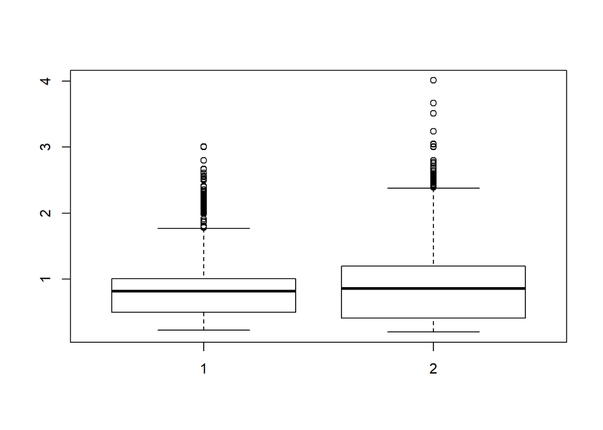

```r
boxplot(good$carat, premium$carat)
```

V veličině `carat` se diamanty příliš neliší - minimum obou variant je skoro stejné, maximum mají Premimum diamanty větší, stejně tak průměr. Prostřední hodnota dat (medián) je vyšší u Premium diamantů, a mezikvartilové rozpětí je u Premium diamantů taky větší - dá se říct, že větší část Premium diamantů se nachází právě mezi 0.41 - 1.2 karáty (výška boxplotu).

```r
summary(good$depth)
```

```
##    Min. 1st Qu.  Median    Mean 3rd Qu.    Max.
##   54.30   61.30   63.40   62.37   63.80   67.00
```

```r
summary(premium$depth)
```

```
##    Min. 1st Qu.  Median    Mean 3rd Qu.    Max.
##   58.00   60.50   61.40   61.26   62.20   63.00
```

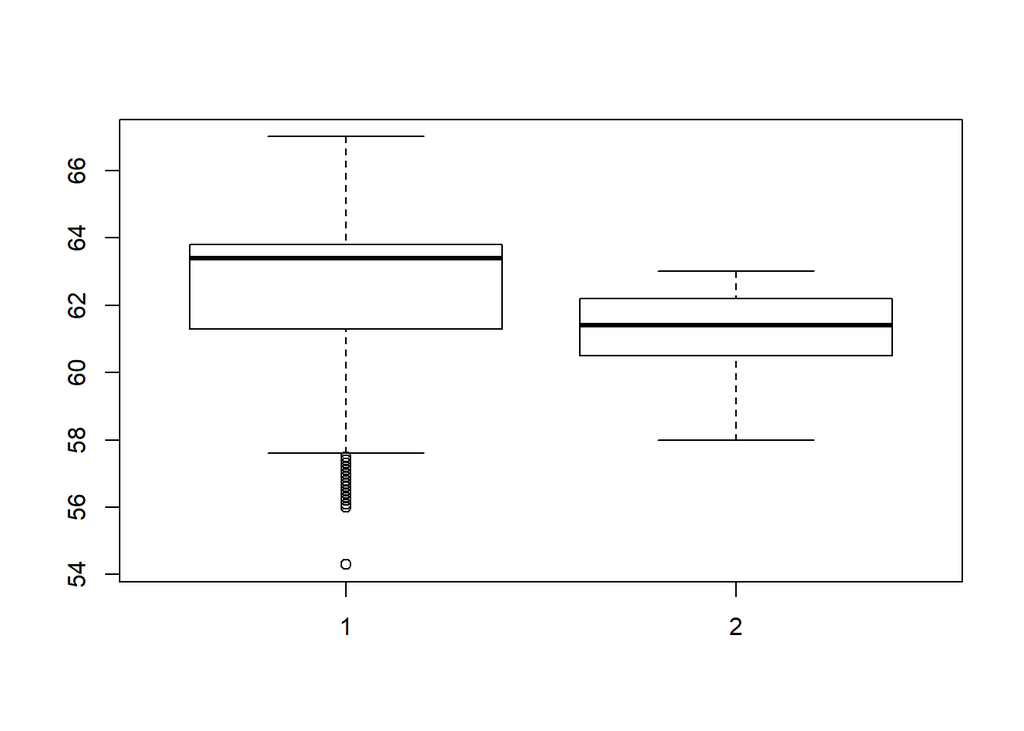

```r
boxplot(good$depth, premium$depth)
```

Nemám tušení, co popisuje veličina `depth` tak se mi těžko interpretují výsledky srovnání. Co je jisté je, že Premium diamanty mají tuto veličinu jednak nižší (nižší medián), a taky se více koncentrují okolo toho mediánu (menší mezikvartilové rozpětí).

```r
summary(good$price)
```

```
##    Min. 1st Qu.  Median    Mean 3rd Qu.    Max.
##     327    1145    3050    3929    5028   18788
```

```r
summary(premium$price)
```

```
##    Min. 1st Qu.  Median    Mean 3rd Qu.    Max.
##     326    1046    3185    4584    6296   18823
```

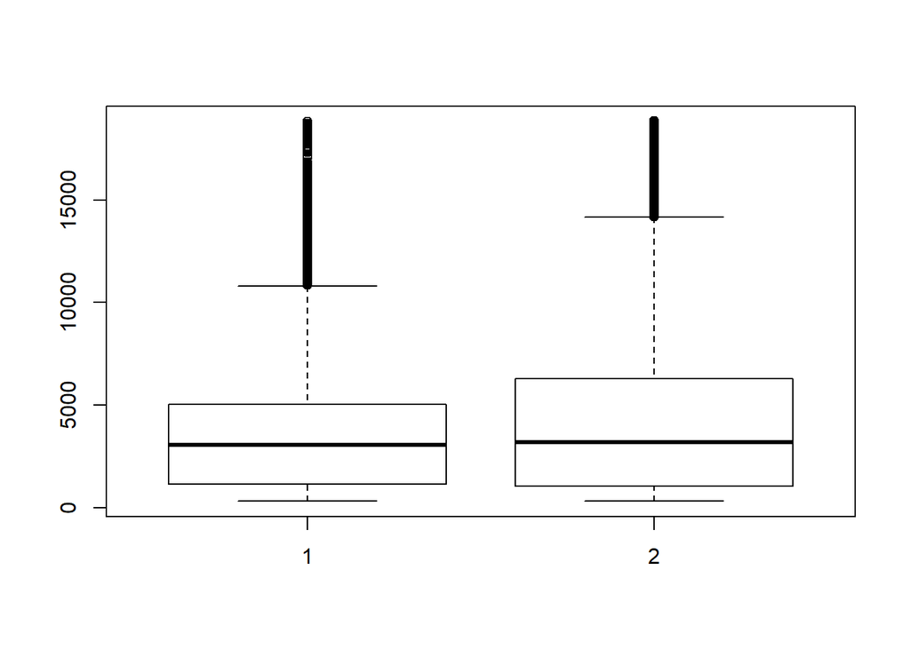

```r
boxplot(good$price, premium$price)
```

## Zadání Teorie

1. Spočítejte pravděpodobnost, že hodíte 6-tku z deseti hodů právě 5 krát. (Použijte eRkové funkce)
2. Spočítejte 0.97 kvantil t rozdělení s parametrem počet stupňů volnosti rovno 15.
3. Spočítejte 0.3 kvantil normálního rozdělení s paremetrem střední hodnota rovno 3 a směrodatnou odchylkou rovnou 20.
4. Jaká je hodnota hustoty prvaděpodobnosti v bodě 0.3 u normálního rozdělení s parametrem střední hodnota rovno 5, kde rozptyl je roven 10.
5. Kolik procent lidí má mzdu pod 50000, pokud předpokládám, že má mzda normální rozdělení s parametrem střední hodnota rovno 40000 a směrodatná odchylka rovna 20000.

## Řešení Teorie

```r
# 1.
dbinom(5, size=10, prob=1/6)
```

```
## [1] 0.01302381
```

```r
# 2.
qt(p=0.97, df=15)
```

```
## [1] 2.034289
```

```r
# 3.
qnorm(p=0.3, mean=3, sd=20)
```

```
## [1] -7.48801
```

```r
# 4. pozn. - zde je zadan rozptyl, pro smerodatnou odchylku jej tedy musime odmocnit
dnorm(0.3, mean=5, sd=sqrt(10))
```

```
## [1] 0.04180534
```

```r
# 5.
pnorm(50000, mean=40000, sd=20000)
```

```
## [1] 0.6914625
```